# Exploratory Data Analysis: `iris`

Eugene Joh

Wednesday, December 05, 2018

# Overview

This parameterized markdown file is a standarized exploratory analysis report, examining the data type, structure, missing values, unique values, summary statistics for continuous and categorical variables contained within a `data.frame` object.

This does not support `date-time` varaibles such as `POSIXct` or `Date`, but will eventually move to support all data types typically found in `data.frame` in the R environment.

# Data Structure

Dataset Dimensions

| Name | Number of Columns | Number of Rows | Number of Elements | Memory Allocation |
| --- | --- | --- | --- | --- |
| iris | 5 | 150 | 750 | 7.1 Kb |

Dataset Variable Class and Missing Values

| Variable | Class | missing |
| --- | --- | --- |
| Sepal.Length | numeric | 0 |
| Sepal.Width | numeric | 0 |
| Petal.Length | numeric | 0 |
| Petal.Width | numeric | 0 |
| Species | factor | 0 |

# Missing Values, Data Type, Unique Values

## Table

The table below displays the data type, counts/proportion of missing values `NA`, and whether the data is labelled or not.

|  | Variable | Missing (n) | Missing (%) | Exist (%) | Data Type | Labelled |
| --- | --- | --- | --- | --- | --- | --- |
| 1 | Sepal.Length | 0 | 0 | 100 | numeric | False |
| 2 | Sepal.Width | 0 | 0 | 100 | numeric | False |
| 3 | Petal.Length | 0 | 0 | 100 | numeric | False |
| 4 | Petal.Width | 0 | 0 | 100 | numeric | False |
| 5 | Species | 0 | 0 | 100 | factor | False |

## Plot

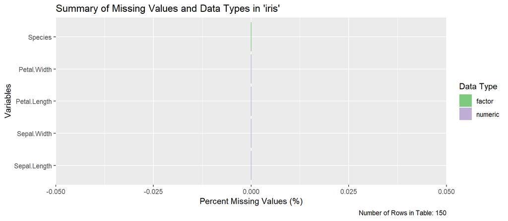

## Unique Values

|  | Variable | Counts | Percentage of Total Rows |
| --- | --- | --- | --- |
| 1 | Sepal.Length | 35 | 23.33 |
| 2 | Sepal.Width | 23 | 15.33 |
| 3 | Petal.Length | 43 | 28.67 |
| 4 | Petal.Width | 22 | 14.67 |
| 5 | Species | 3 | 2 |

# Variable Content

This section contains an analysis of the variable content composition by describing the type of data content that exist based on **numeric** values, **character** values, **punctuation** or **symbols**, and **blank** space. This is especially useful when data types are not identified or misclassified.

## Only Numbers

**only_numbs** reports the number of rows that contain only digits `"^[0-9]{1,}$"` and **numpercent** is the respective percentage. **digits_min** and **digits_max** display the length of the digits found in the variable, **digits_eq** is a logical statment of whether the mix and max are equal.

|  | variable | only_numbs | n_row | numpercent | digits_min | digits_max | digits_eq |
| --- | --- | --- | --- | --- | --- | --- | --- |
| 1 | Sepal.Length | 150 | 150 | 100 | 1 | 1 | True |
| 2 | Sepal.Width | 150 | 150 | 100 | 1 | 1 | True |
| 3 | Petal.Length | 150 | 150 | 100 | 1 | 1 | True |
| 4 | Petal.Width | 150 | 150 | 100 | 1 | 1 | True |
| 5 | Species | 0 | 150 | 0 |  |  | False |

## Only Character

**only_char** reports the number of rows that contain only characters `"^[A-z]{1,}"` and **charpercent** is the respective percentage.

|  | variable | only_char | n_row | charpercent |
| --- | --- | --- | --- | --- |
| 1 | Sepal.Length | 0 | 150 | 0 |
| 2 | Sepal.Width | 0 | 150 | 0 |
| 3 | Petal.Length | 0 | 150 | 0 |
| 4 | Petal.Width | 0 | 150 | 0 |
| 5 | Species | 150 | 150 | 100 |

## Only Punctuation

**only_punc** reports the number of rows that contain only punctuation or symbols `"^\\W+$"` and **puncpercentage** is the respective percentage.

|  | variable | only_punc | n_row | puncpercent |
| --- | --- | --- | --- | --- |
| 1 | Sepal.Length | 0 | 150 | 0 |
| 2 | Sepal.Width | 0 | 150 | 0 |
| 3 | Petal.Length | 0 | 150 | 0 |
| 4 | Petal.Width | 0 | 150 | 0 |
| 5 | Species | 0 | 150 | 0 |

## Only Blanks

**only_blanks** reports the number of rows that contain a blank ("") `"^\\s{0}$"` and **blankspercent** is the respective percentage. **only_wspace** reports the number of rows that contain any white-space, including a blank `"^\\s*$"` and **wspacepercent** is the respective percentage.

|  | variable | only_blanks | blankspercent | only_wspace | wspacepercent |
| --- | --- | --- | --- | --- | --- |
| 1 | Sepal.Length | 0 | 0 | 0 | 0 |
| 2 | Sepal.Width | 0 | 0 | 0 | 0 |
| 3 | Petal.Length | 0 | 0 | 0 | 0 |
| 4 | Petal.Width | 0 | 0 | 0 | 0 |
| 5 | Species | 0 | 0 | 0 | 0 |

## All Types

|  | variable | only_numbs | numpercent | digits_min | digits_max | digits_eq | only_char | charpercent | only_punc | puncpercent | only_blanks | blankspercent | only_wspace | wspacepercent |
| --- | --- | --- | --- | --- | --- | --- | --- | --- | --- | --- | --- | --- | --- | --- |
| 1 | Sepal.Length | 150 | 100 | 1 | 1 | True | 0 | 0 | 0 | 0 | 0 | 0 | 0 | 0 |
| 2 | Sepal.Width | 150 | 100 | 1 | 1 | True | 0 | 0 | 0 | 0 | 0 | 0 | 0 | 0 |
| 3 | Petal.Length | 150 | 100 | 1 | 1 | True | 0 | 0 | 0 | 0 | 0 | 0 | 0 | 0 |
| 4 | Petal.Width | 150 | 100 | 1 | 1 | True | 0 | 0 | 0 | 0 | 0 | 0 | 0 | 0 |
| 5 | Species | 0 | 0 |  |  | False | 150 | 100 | 0 | 0 | 0 | 0 | 0 | 0 |

# Variable Content Plot

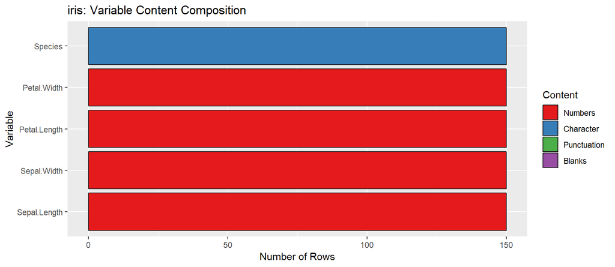

# Continuous Variables

## Sepal.Length

Summary Statistics for Sepal.Length

| Min | Mean | Median | Max | Standard Deviation |
| --- | --- | --- | --- | --- |
| 4.3 | 5.84 | 5.8 | 7.9 | 0.83 |

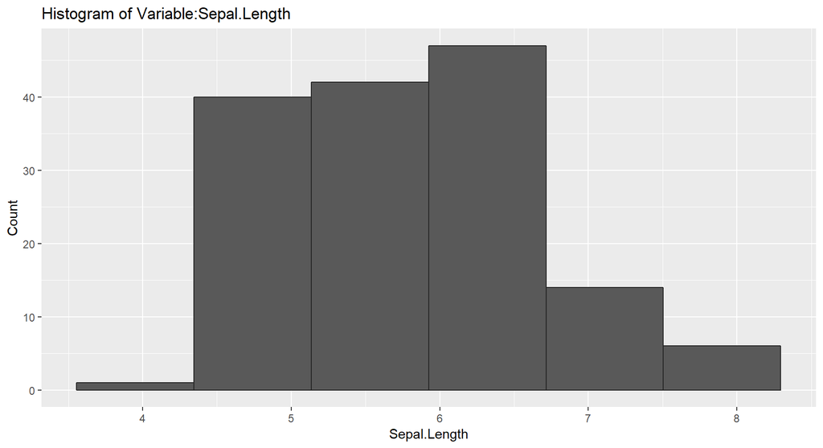

## Sepal.Width

Summary Statistics for Sepal.Width

| Min | Mean | Median | Max | Standard Deviation |
| --- | --- | --- | --- | --- |
| 2 | 3.06 | 3 | 4.4 | 0.44 |

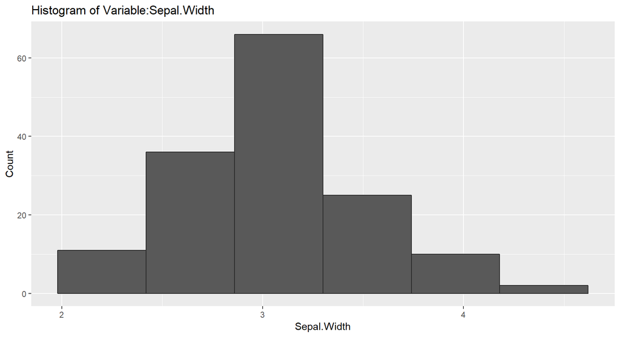

## Petal.Length

Summary Statistics for Petal.Length

| Min | Mean | Median | Max | Standard Deviation |
| --- | --- | --- | --- | --- |
| 1 | 3.76 | 4.35 | 6.9 | 1.77 |

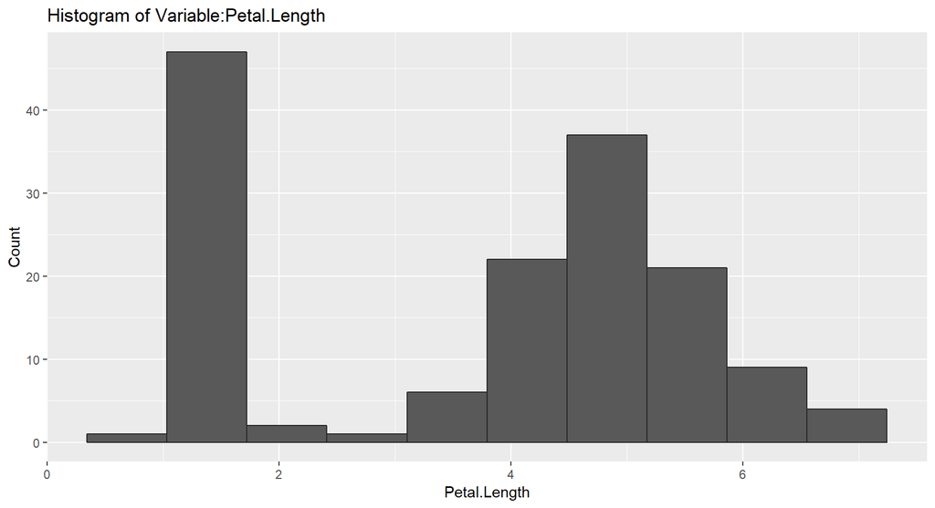

## Petal.Width

Summary Statistics for Petal.Width

| Min | Mean | Median | Max | Standard Deviation |
| --- | --- | --- | --- | --- |
| 0.1 | 1.2 | 1.3 | 2.5 | 0.76 |

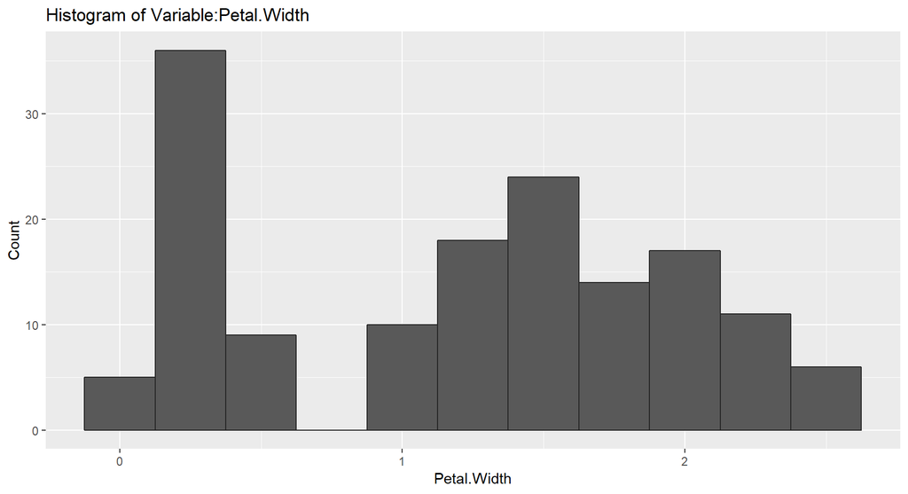

```r
if (length(names(dplyr::select_if(params$dat, funs(is.character(.) | is.factor(.))))) == 0) {
  cat_log <- FALSE
}
```

# Categorical Variables

## Species

Counts and Proportion for Top 10: Species

| Species | n | percent |
| --- | --- | --- |
| setosa | 50 | 33.33 |
| versicolor | 50 | 33.33 |
| virginica | 50 | 33.33 |

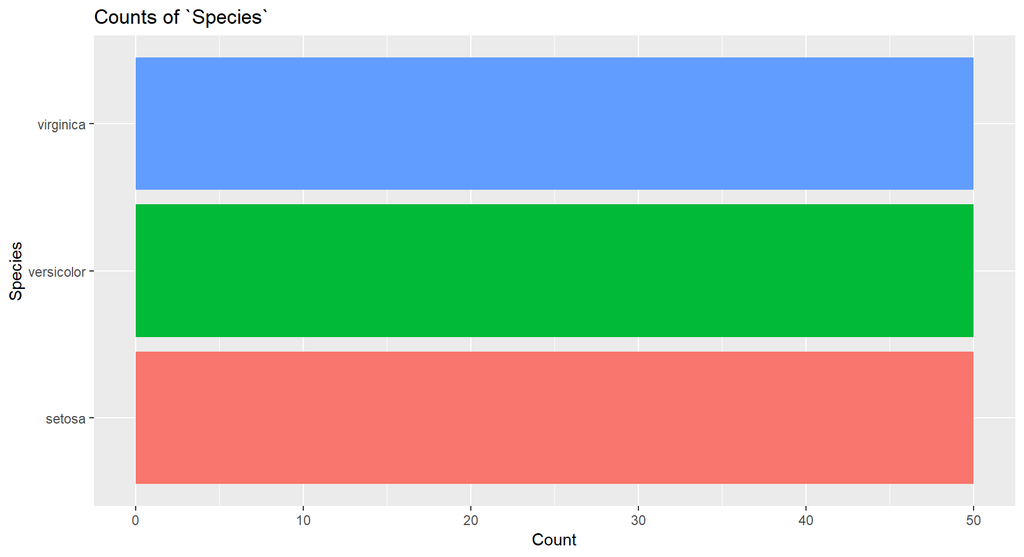

Process Time: 0.3 minutes  
R version 3.5.1 (2018-07-02)  
Report by the Centre for Global Health Research